# Idiographic TNA of Master’s Thesis Writing

Author

Affiliation

[Hibiki Ito](https://sites.google.com/view/hibiki-ito/home)

Kyoto University

This is the supplementary material for the paper “[Exploring Idiographic Learning Analytics in Master’s Thesis Writing: A Transition Network Approach](https://researchmap.jp/hibiki.ito/published_papers/51232846?lang=en)” by Ito, H. (in press). The work is presented at the International Conference on Smart Learning Environments (ICSLE) 2025.

### Download datasets

- ema.csv: Ecological momentary assessment (EMA) data.
- web.csv: Web trace data.

### Context of the study

Data of a master’s degree student (N=1) were collected over the period of approximately six months during their master’s thesis work. EMA, a smart watch and a web usage tracking app were used for data collection. Table 1 shows the measured constructs and descriptions in the EMA survey, and Table 2 summarises the collected data. Refer to the paper for more context.

**Table 1. Measured constructs and corresponding descriptions in the EMA survey**

| Construct | Description in the questionnaire |
| --- | --- |
| Expectancy | I believe I can accomplish my learning duties and learning tasks efficiently |
| Value | I believe I can accomplish my learning duties and learning tasks efficiently |
| Tracking | I am keeping track of what I need to do or accomplish |
| Planning | I know what I have to do to accomplish my learning tasks |
| Effort | I am putting enough effort into my learning tasks to accomplish them well |
| Focus | I am focusing on performing my learning tasks today and resisting distractions |
| Help | I seek help from teachers, friends or the Internet when I need explanation or help with difficult tasks |
| Environment | I am having nice interactions and feeling home within the university community |
| Organising | I am doing my studies in time and keeping with the tasks/deadlines |
| Motivation | I feel enthusiastic/motivated to learn, understand and get better grades |
| Anxiety | I feel anxious/stressed working on learning tasks, assignments or at work |
| Enjoyment | I enjoy my tasks and feel happy about my achievements work/accomplishment |
| Feedback | I am learning from feedback to accomplish my learning |
| Metacognition | I always assess my performance or work in tasks in order to improve my skills |

**Table 2. Summary of collected data**

[output not shown]

In the following, we go through preprocessing and analyses to reproduce the results in the paper.

# 0 Data wrangling and preprocessing

Import libraries:

```r
library(tidyverse)     # data manipulation, wrangling and visualisation
library(skimr)         # data wrangling
library(corrplot)      # correlation visualisation
library(dendextend)    # dendrogram visualisation helper
library(gt)            # displays tables
library(RColorBrewer)  # for colouring
library(tsn)           # time series analysis
library(tna)           # transition network analysis
library(cluster)       # Silhouette analysis
library(fmsb)          # radar charts
source("src/utils.R")    # helper for detrending (https://github.com/lamethods/advanced-labook-code/blob/main/ch20-var/aux.R)
```

## 0.1 EMA data

Summary statistics of EMA data:

```r
ema <- read_csv("data/ema.csv")
ema_summary <- skim(ema)
print(ema_summary)
```

```
── Data Summary ────────────────────────
                           Values
Name                       ema
Number of rows             334
Number of columns          19
_______________________
Column type frequency:
  difftime                 1
  numeric                  18
________________________
Group variables            None

── Variable type: difftime ─────────────────────────────────────────────────────
  skim_variable n_missing complete_rate min        max        median
1 Time                  0             1 31740 secs 79620 secs 48960 secs
  n_unique
1      254

── Variable type: numeric ──────────────────────────────────────────────────────
   skim_variable         n_missing complete_rate    mean      sd   p0  p25   p50
 1 Date                          0             1   78.1    48.9   1   33.2  73
 2 Expectancy                    0             1    7.36    1.04  3    7     7.5
 3 Value                         0             1    8.43    1.21  4    8     9
 4 Tracking                      0             1    7.27    1.57  3    6     8
 5 Planning                      0             1    7.78    1.68  2    7     8
 6 Effort                        0             1    7.69    1.33  3    7     8
 7 Focus                         0             1    6.73    1.66  2    6     7
 8 Help                          0             1    5.92    1.52  2    5     6
 9 Environment                   0             1    6.52    2.12  2    5     7
10 Organising                    0             1    5.63    1.50  1    5     6
11 Motivation                    0             1    7.95    1.68  3    7     8
12 Anxiety                       0             1    4.52    1.75  1    3     4
13 Enjoyment                     0             1    7.50    1.51  2    7     8
14 Feedback                      0             1    5.83    2.92  1    3     6
15 Metacognition                 0             1    5.77    1.43  2    5     6
16 Exercise_last_2h              0             1    4.80    7.30  0    0     1
17 Avg_heartrate_last_2h         0             1   67.5    19.8  40.1 48.2  67.8
18 Stepcount_last_2h             0             1 1402.   1547.    0   48.2 754
      p75  p100 hist
 1  125.   158  ▇▆▆▅▇
 2    8     10  ▁▁▇▇▂
 3    9     10  ▁▁▂▅▇
 4    8     10  ▁▂▆▇▅
 5    9     10  ▁▂▂▇▇
 6    9     10  ▁▁▆▇▆
 7    8     10  ▁▅▃▇▂
 8    7     10  ▂▇▇▇▁
 9    8     10  ▂▇▃▇▅
10    7      9  ▁▅▅▇▂
11    9     10  ▁▁▅▅▇
12    6      8  ▃▅▇▃▃
13    9     10  ▁▂▂▇▅
14    8     10  ▆▅▅▇▆
15    7     10  ▁▇▆▅▁
16    8     44  ▇▂▁▁▁
17   79.8  159. ▆▇▂▁▁
18 2624.  6170  ▇▂▂▁▁
```

As there are too many variables, we explore correlations between variables from the questionnaire to reduce the number of variables.

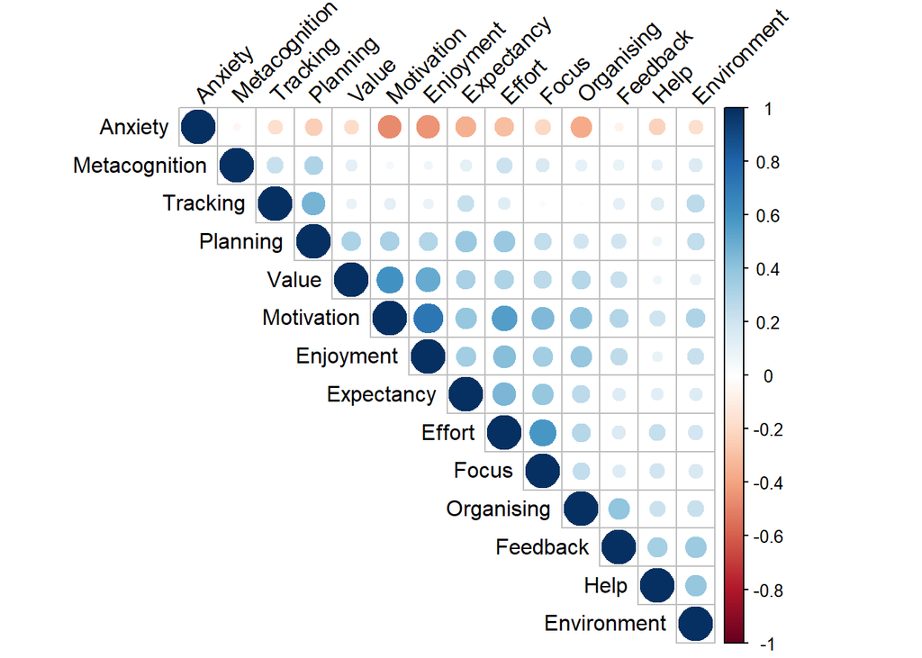

```r
questionnaire_vars <- c(
  "Expectancy", "Value", "Tracking", "Planning", "Effort", "Focus",
  "Help", "Environment", "Organising", "Motivation",
  "Anxiety", "Enjoyment", "Feedback", "Metacognition"
)
ema_questionnaire <- ema |> select(all_of(questionnaire_vars))

corr_mat <- cor(
  ema_questionnaire,
  use   = "pairwise.complete.obs",
  method = "pearson"
)
corrplot(
  corr_mat,
  type   = "upper",
  order  = "hclust",
  tl.col = "black",
  tl.srt = 45
)
```

Applying hierarchical clustering using correlations as a similarity metric, we identify five clusters which plausibly group similar, correlated constructs.

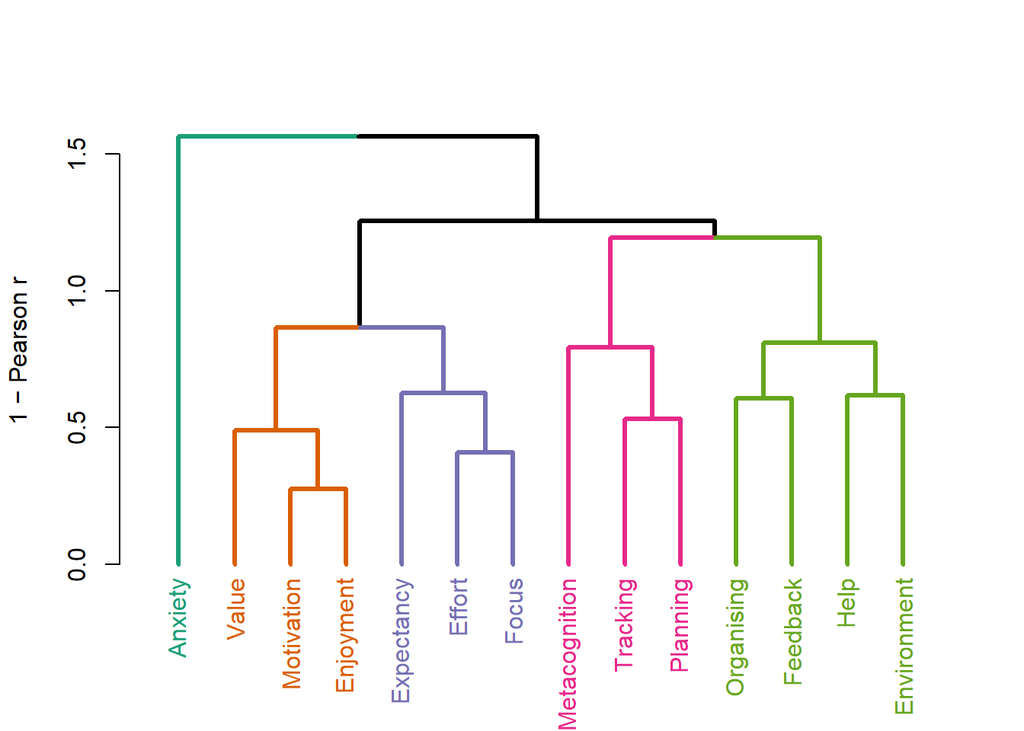

```r
dist_mat <- as.dist(1 - corr_mat)
hc <- hclust(dist_mat, method = "ward.D2")

k <- 5
cols <- brewer.pal(k, "Dark2")
dend <- as.dendrogram(hc) |>
  color_branches(k = k, col = cols) |>
  set("branches_lwd", 3)

labels_colors(dend) <- get_leaves_branches_col(dend)
plot(
  dend,
  ylab = "1 − Pearson r"
)
```

We name the identified clusters as follows:

| Anxiety | Attraction | Commitment | Regulation | Support |
| --- | --- | --- | --- | --- |
| Anxiety | Value, Motivation, Enjoyment | Expectancy, Effort, Focus | Metacognition, Tracking, Planning | Organising, Feedback, Help, Environment |

## 0.2 Web trace data

Summary statistics of the web trace data:

```r
web <- read_csv("data/web.csv")
web_summary <- skim(web)
print(web_summary)
```

```
── Data Summary ────────────────────────
                           Values
Name                       web
Number of rows             132
Number of columns          5
_______________________
Column type frequency:
  numeric                  5
________________________
Group variables            None

── Variable type: numeric ──────────────────────────────────────────────────────
  skim_variable n_missing complete_rate  mean    sd p0  p25  p50   p75 p100
1 Date                  0             1  78.6  47.8  1 34.8 77.5 122.   158
2 ChatGPT               0             1  20.7  33.6  0  5   12    25.2  332
3 Overleaf              0             1 109.  139.   0  0   35.5 194.   692
4 Notion                0             1  12.6  17.7  0  2    6    16.5  108
5 Paperpile             0             1  77.4  94.5  0  3   42.5 121    505
  hist
1 ▇▆▇▆▇
2 ▇▁▁▁▁
3 ▇▂▂▁▁
4 ▇▁▁▁▁
5 ▇▂▁▁▁
```

Cumulative time spent on each activity:

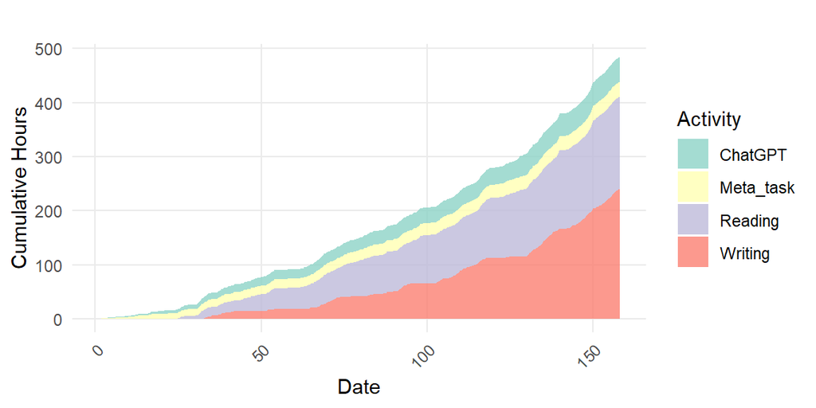

```r
colnames(web) <- c("Date", "ChatGPT", "Writing", "Meta_task", "Reading")
web_cum <- web |>
  arrange(Date) |>
  mutate(
    Writing_cum = cumsum(Writing) / 60,
    Total_cum = cumsum(ChatGPT + Writing + Meta_task + Reading) / 60
  )

web_cum <- web |>
  arrange(Date) |>
  mutate(
    ChatGPT       = cumsum(ChatGPT)       / 60,
    Writing   = cumsum(Writing)   / 60,
    Meta_task = cumsum(Meta_task) / 60,
    Reading   = cumsum(Reading)   / 60
  )

web_cum_long <- web_cum |>
  pivot_longer(
    cols      = -Date,
    names_to  = "Activity",
    values_to = "Hours"
  )

ggplot(web_cum_long, aes(x = Date, y = Hours, fill = Activity)) +
  geom_area(position = "stack", alpha = 0.8) +
  scale_fill_brewer(palette = "Set3") +
  labs(
    title    = "",
    x        = "Date",
    y        = "Cumulative Hours",
    fill     = "Activity"
  ) +
  theme_minimal() +
  theme(
    axis.text.x      = element_text(angle = 45, hjust = 1),
    panel.grid.minor = element_blank()
  )
```

# 1 Within-feature TNA

In this section, we aim to answer the following research question:

- **RQ1**: How does each EMA feature change within a day and between days?

First we detrend and standardise the features by the ordinary least squares linear regression following [the tutorial by Saqr et al.](https://lamethods.org/book2/chapters/ch20-var/ch20-var.html)

```r
df <- ema |>
  mutate(
    Regulation = (Metacognition + Tracking + Planning) / 3,
    Attraction = (Value + Motivation + Enjoyment) / 3,
    Commitment = (Expectancy + Effort + Focus) / 2,
    Support = (Organising + Help + Feedback + Environment) / 4
  )

df_detrended <- detrender(df, vars = cluster_names, timevar = "Date") |>
  select(ends_with("_detrended")) |>
  rename_with(~ gsub("_detrended$", "", .)) |>
  scale() |>
  as.data.frame() |>
  mutate(Date = df$Date)
```

```
Detrending variable Anxiety - p-value: 0.00513486532843699
```

```
Detrending variable Attraction - p-value: 0.00340834726335778
```

```
No significant trend for Commitment - p-value: 0.374127913785403
```

```
Detrending variable Regulation - p-value: 6.69582322748843e-11
```

```
Detrending variable Support - p-value: 0.0241384011003202
```

Classify data points into three states: low, average and high.

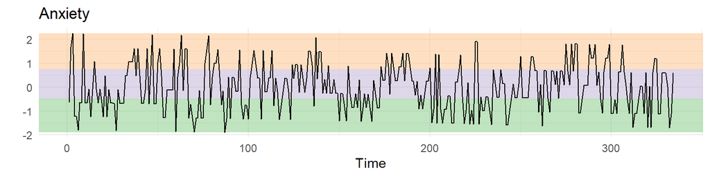

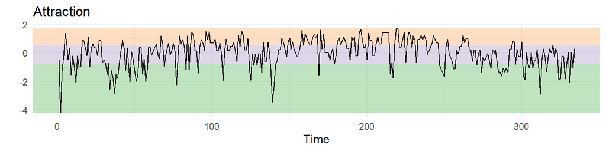

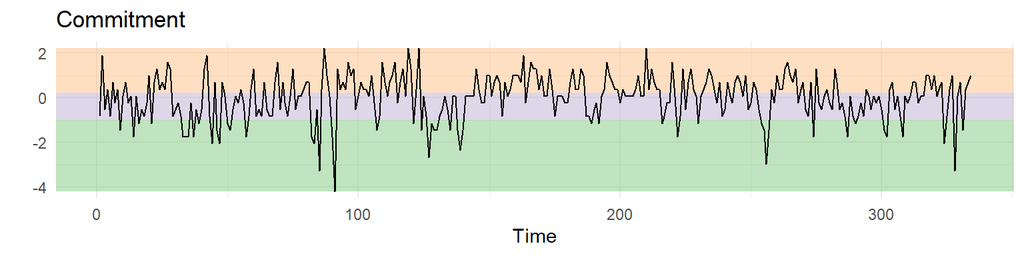

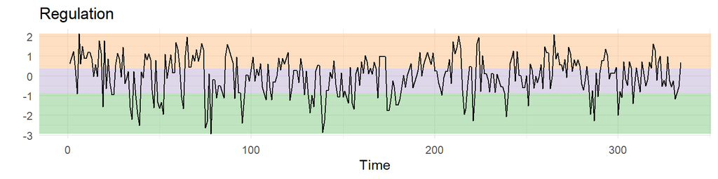

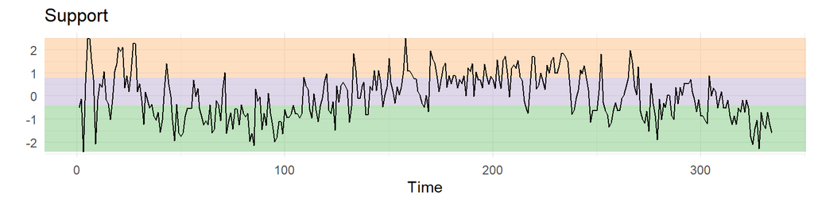

```r
set.seed(123)
for (var in cluster_names) {
  df_tmp <- discretize(
    df_detrended, n_states = 3, method = "kmeans", value_col = var
    )

  state_col <- paste0(var, "_state")
  centres <- df_tmp |>
    group_by(!!sym(state_col)) |>
    summarise(centres = mean(!!sym(var), na.rm=TRUE)) |>
    arrange(centres)
  df_tmp[[state_col]] <- factor(
    df_tmp[[state_col]],
    levels = centres[[state_col]],
    labels = c("low", "average", "high")
  )

  # Plot the time series
  p <- plot_series(df_tmp, overlay = "h") +
    ggtitle(var) +
    theme(
      legend.position = "none",
    )
  print(p)

  # Store cluster assignments
  df_detrended[[state_col]] <- df_tmp[[state_col]]
}
```

Visualise transition networks for each feature:

```
── Preparing Data ──────────────────────────────────────────────────────────────
```

```
ℹ Input data dimensions: 334 rows, 11 columns
ℹ No `time` or `order` column provided. Using `actor` as a session identifier.
ℹ Total number of sessions: 132
ℹ Number of unique users: 132
ℹ Total number of actions: 334
ℹ Maximum sequence length: 5 actions
```

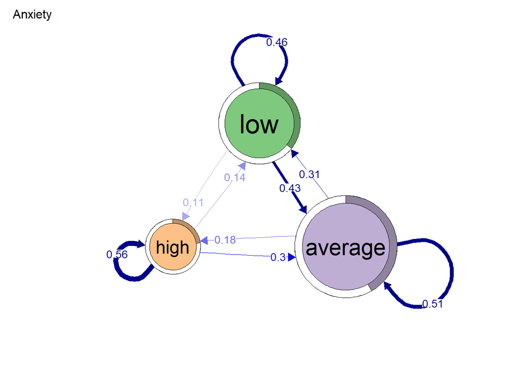

```
── Preparing Data ──────────────────────────────────────────────────────────────
ℹ Input data dimensions: 334 rows, 11 columnsℹ No `time` or `order` column provided. Using `actor` as a session identifier.ℹ Total number of sessions: 132ℹ Number of unique users: 132ℹ Total number of actions: 334ℹ Maximum sequence length: 5 actions
```

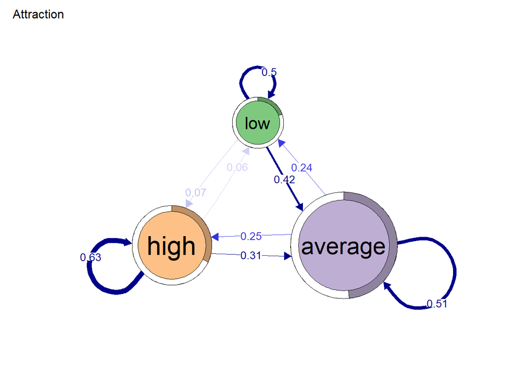

```
── Preparing Data ──────────────────────────────────────────────────────────────
ℹ Input data dimensions: 334 rows, 11 columnsℹ No `time` or `order` column provided. Using `actor` as a session identifier.ℹ Total number of sessions: 132ℹ Number of unique users: 132ℹ Total number of actions: 334ℹ Maximum sequence length: 5 actions
```

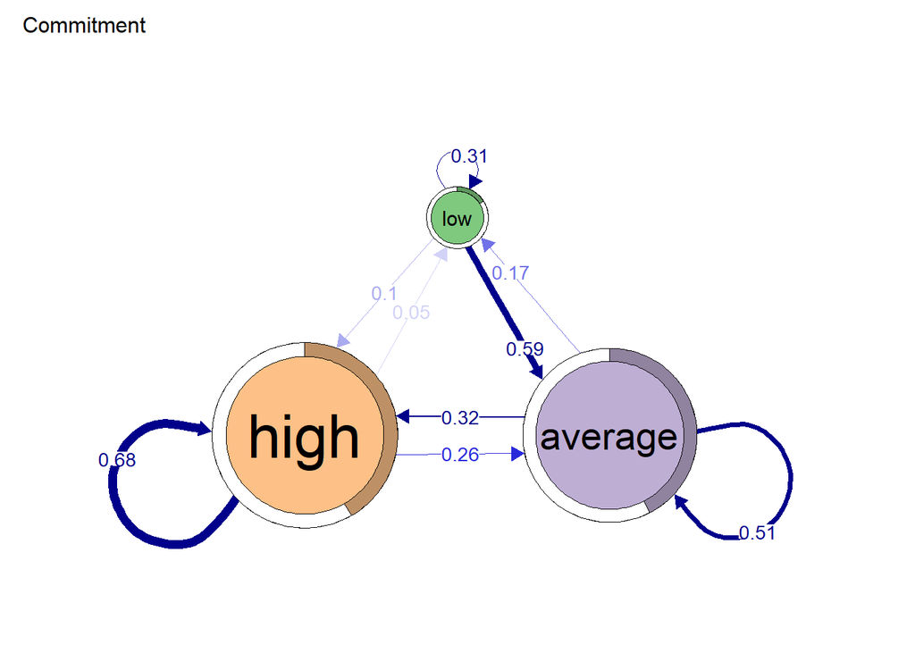

```
── Preparing Data ──────────────────────────────────────────────────────────────
ℹ Input data dimensions: 334 rows, 11 columnsℹ No `time` or `order` column provided. Using `actor` as a session identifier.ℹ Total number of sessions: 132ℹ Number of unique users: 132ℹ Total number of actions: 334ℹ Maximum sequence length: 5 actions
```

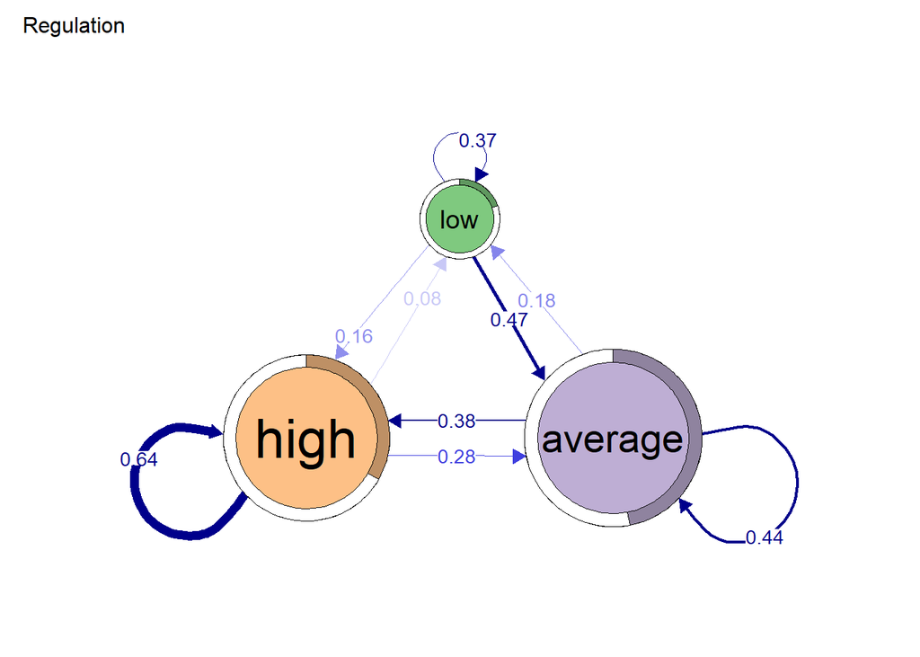

```
── Preparing Data ──────────────────────────────────────────────────────────────
ℹ Input data dimensions: 334 rows, 11 columnsℹ No `time` or `order` column provided. Using `actor` as a session identifier.ℹ Total number of sessions: 132ℹ Number of unique users: 132ℹ Total number of actions: 334ℹ Maximum sequence length: 5 actions
```

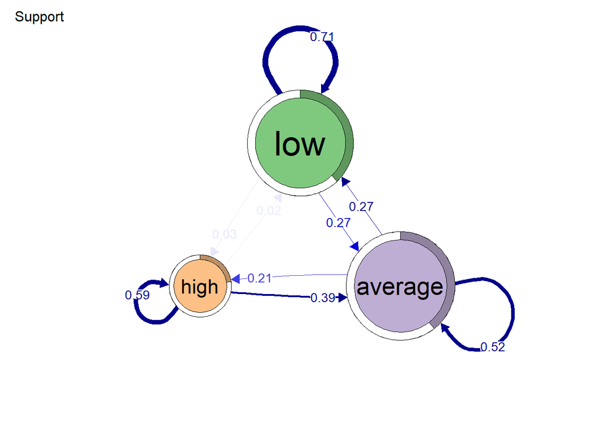

```r
for (var in cluster_names) {
  action <- paste0(var, "_state")
  net_data <- prepare_data(df_detrended, action = action, actor = "Date")
  net <- tna(net_data)
  plot(
    net,
    vsize       = table(df_detrended[[action]]) * 0.15,
    layoutScale = 0.5,
    title       = var
  )
}
```

# 2 TNA over learning states

In this section, we address the following research question:

- **RQ2**: What are learning states and how do they unfold within a day and between days?

First detrend and standardise all features:

```r
reduced_ema_vars <- c("Anxiety", "Regulation", "Attraction", "Commitment",
                      "Support", "Exercise_last_2h", "Stepcount_last_2h",
                      "Avg_heartrate_last_2h")
df_processed <- detrender(df, vars = reduced_ema_vars, timevar = "Date") |>
  select(ends_with("_detrended")) |>
  rename_with(~ gsub("_detrended$", "", .)) |>
  scale() |>
  as.data.frame()
```

```
Detrending variable Anxiety - p-value: 0.00513486532843699
```

```
Detrending variable Regulation - p-value: 6.69582322748843e-11
```

```
Detrending variable Attraction - p-value: 0.00340834726335778
```

```
No significant trend for Commitment - p-value: 0.374127913785403
```

```
Detrending variable Support - p-value: 0.0241384011003202
```

```
Detrending variable Exercise_last_2h - p-value: 0.000918863835341057
```

```
Detrending variable Stepcount_last_2h - p-value: 0.0010130843753585
```

```
Detrending variable Avg_heartrate_last_2h - p-value: 0.000107798952204481
```

Show the elbow plot of k-means clustering:

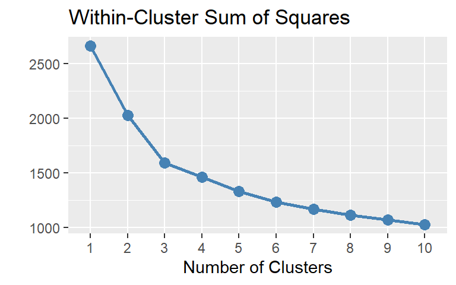

```r
set.seed(123)
cluster_range <- 1:10
mean_euc_dist <- numeric(length(cluster_range))

for (k in cluster_range) {
  km <- kmeans(df_processed, centers = k, nstart = 25)
  clust <- km$cluster
  centers <- km$centers
  dists <- rowSums((df_processed - centers[clust, ])^2)
  mean_euc_dist[k] <- sum(dists)
}

elbow_df <- data.frame(
  Clusters        = cluster_range,
  MeanEucDistance = mean_euc_dist
)

ggplot(elbow_df, aes(x = factor(Clusters), y = MeanEucDistance, group = 1)) +
  geom_line(linewidth = 1, color = "steelblue") +
  geom_point(size = 3, color = "steelblue") +
  scale_x_discrete(drop = FALSE) +
  labs(title = "Within-Cluster Sum of Squares",
       x     = "Number of Clusters",
       y     = "")
```

According to the above elbow plot, we set $k=3$. Show the radar chart:

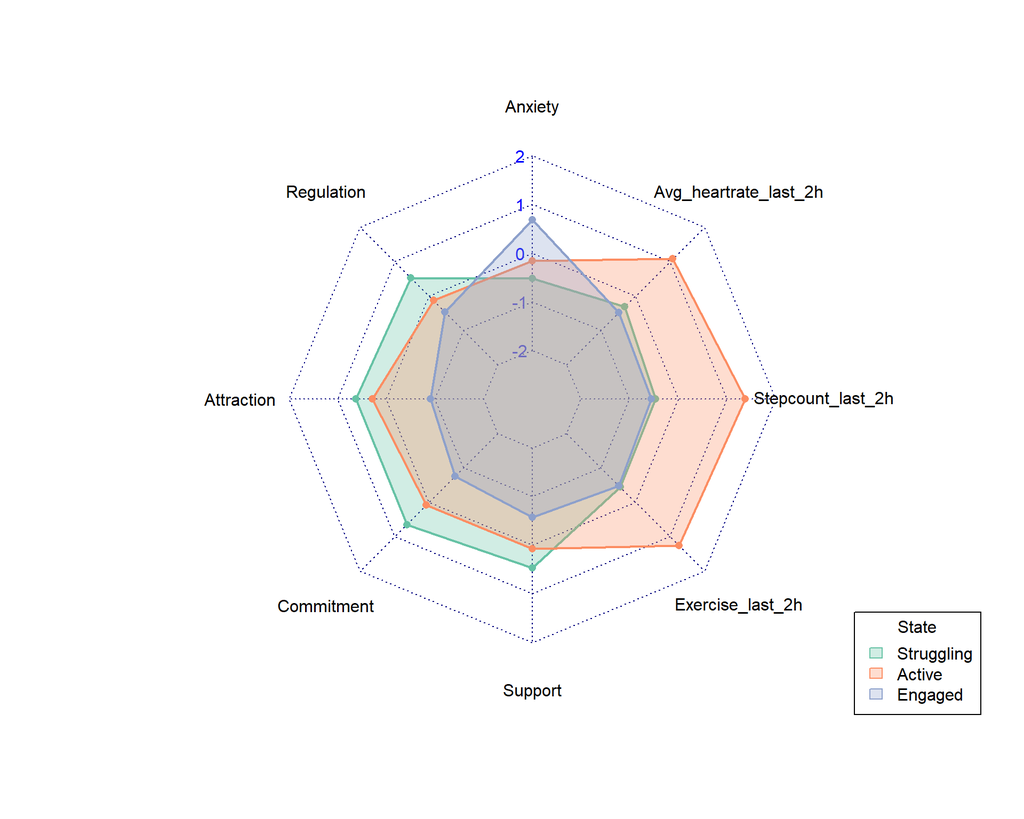

```r
set.seed(123)
k <- 3
km <- kmeans(df_processed, centers = k, nstart = 25)
df_processed <- df_processed |> mutate(State = km$cluster)

cluster_summary <- df_processed |>
  group_by(State) |>
  summarise(across(where(is.numeric), \(x) mean(x, na.rm = TRUE)))

data_for_radar <- cluster_summary |>
  tibble::column_to_rownames("State")

gmin <- -2; gmax <- 2
maxmin_df <- data.frame(
  matrix(
    c( rep(gmax, ncol(data_for_radar)),
       rep(gmin, ncol(data_for_radar)) ),
    nrow    = 2,
    byrow   = TRUE,
    dimnames = list(c("max","min"), colnames(data_for_radar))
  )
)
radar_data <- rbind(maxmin_df, data_for_radar)

state_cols <- brewer.pal(k, "Set2")
fill_cols <- scales::alpha(state_cols, 0.3)

radarchart(
  radar_data,
  axistype = 1,
  seg = 4,
  caxislabels = c(gmin, -1, 0, 1, gmax),
  pcol  = state_cols,
  pfcol = fill_cols,
  plwd  = 2,
  plty  = rep(1, k),
  vlcex = 1,
  title = ""
)
legend(
  "bottomright",
  title  = "State",
  legend = c("Struggling", "Active", "Engaged"),
  fill   = fill_cols,
  border = state_cols,
)
```

The intra-day transition network is shown below. By setting `actor = "Date"`, each day is considered as an individual unit.

```r
df_states <- df_processed |>
  mutate(
    State = factor(
      State,
      levels = 1:k,
      labels = c("Struggling", "Active", "Engaged")
    ),
    Date = df$Date
  )
tna_data <- prepare_data(df_states, action = "State", actor = "Date")
```

```
── Preparing Data ──────────────────────────────────────────────────────────────
```

```
ℹ Input data dimensions: 334 rows, 10 columns
ℹ No `time` or `order` column provided. Using `actor` as a session identifier.
ℹ Total number of sessions: 132
ℹ Number of unique users: 132
ℹ Total number of actions: 334
ℹ Maximum sequence length: 5 actions
```

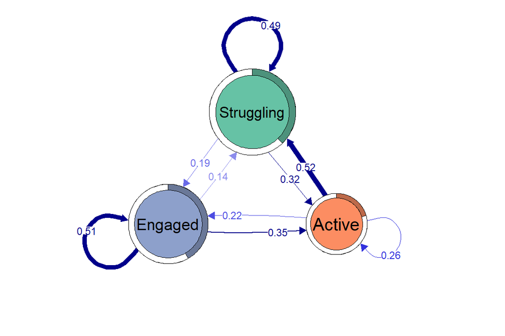

```r
net <- tna(tna_data)

plot(
  net,
  colors = state_cols,
  vsize = table(df_states[["State"]]) * 0.15,
  layoutScale = 0.5
  )
```

In contrast, the following is the inter-day transition network.

```r
tna_data <- prepare_data(df_states, action = "State")
```

```
── Preparing Data ──────────────────────────────────────────────────────────────
```

```
ℹ Input data dimensions: 334 rows, 10 columns
ℹ No `time` or `order` column provided. Treating the entire dataset as one
  session.
ℹ Total number of sessions: 1
ℹ Total number of actions: 334
ℹ Maximum sequence length: 334 actions
```

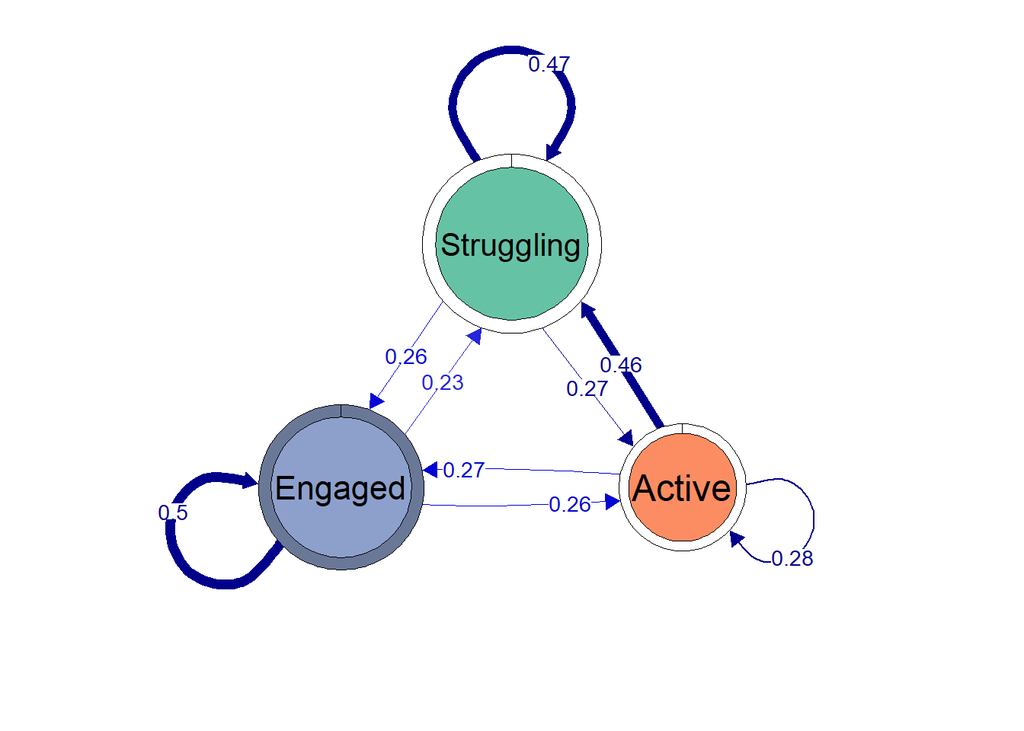

```r
net <- tna(tna_data)

plot(
  net,
  colors = state_cols,
  vsize = table(df_states[["State"]]) * 0.15,
  layoutScale = 0.5
  )
```

Visualise the EMA records by the identified states to see how they unfold over time.

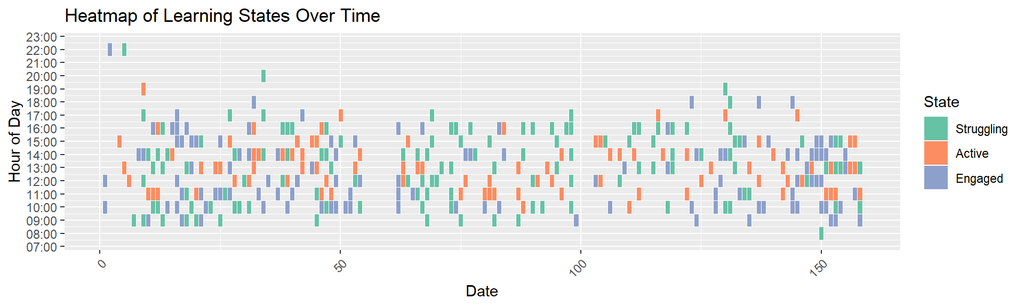

```r
modefun <- function(x) {
  ux <- unique(x)
  ux[which.max(tabulate(match(x, ux)))]
}

df_states <- df_states |>
  mutate(Date = df$Date, Hour = hour(df$Time))

grouped <- df_states |>
  group_by(Date, Hour) |>
  summarise(State_mode = modefun(State),
            .groups = "drop")

ggplot(grouped, aes(x = Date, y = Hour, fill = State_mode)) +
  geom_tile(color = "white") +
  scale_y_continuous(breaks = 0:23,
                     labels = sprintf("%02d:00", 0:23)) +
  scale_fill_manual(values = state_cols, name = "State") +
  labs(title = "Heatmap of Learning States Over Time",
       x = "Date", y = "Hour of Day") +
  theme(axis.text.x = element_text(angle = 45, hjust = 1))
```

# 3 TNA by daily activity profiles

Finally, the following research question is addressed in this section:

- **RQ3**: How do the learning states unfold within a day and between days according to different daily activity profiles?

We utilise the web trace data to determine daily activity profiles. Below we show the violin plot of the variables.

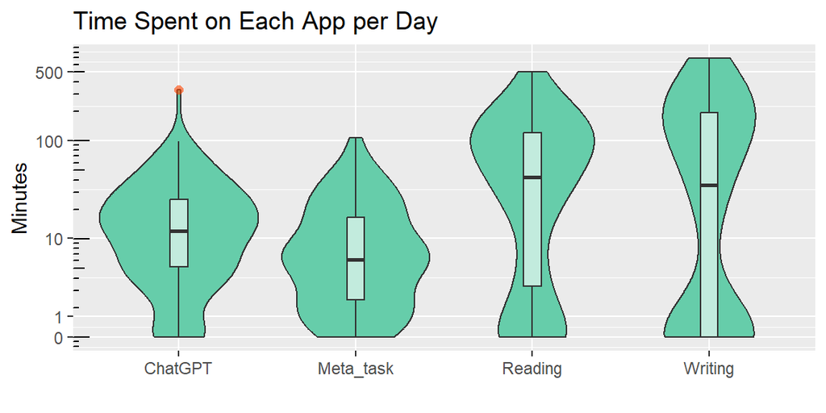

```r
web_vars <- c("Reading", "Meta_task", "ChatGPT", "Writing")
web_long <- web |>
  pivot_longer(cols = all_of(web_vars),
               names_to = "App",
               values_to = "Time")
ggplot(web_long, aes(x = App, y = Time)) +
  geom_violin(fill = "aquamarine3", trim = TRUE) +
  geom_boxplot(
    width          = 0.10,
    outlier.shape  = 16,
    outlier.size   = 2,
    outlier.colour = "orangered",
    fill           = "white",
    alpha          = 0.6
  ) +
  scale_y_continuous(
    trans  = scales::pseudo_log_trans(base = 10),
    breaks = c(0, 1, 10, 100, 500),
    labels = scales::comma_format()
  ) +
  annotation_logticks(sides = "l", short = unit(0.1, "cm")) +
  labs(title = "Time Spent on Each App per Day", x = "", y = "Minutes")
```

The above plot indicates that it is plausible to log-normalise the variables and then standardise.

```r
web_processed <- web |>
  mutate(across(all_of(web_vars), log1p)) |>
  scale() |>
  as.data.frame()
```

Apply hierarchical clustering on the processed data:

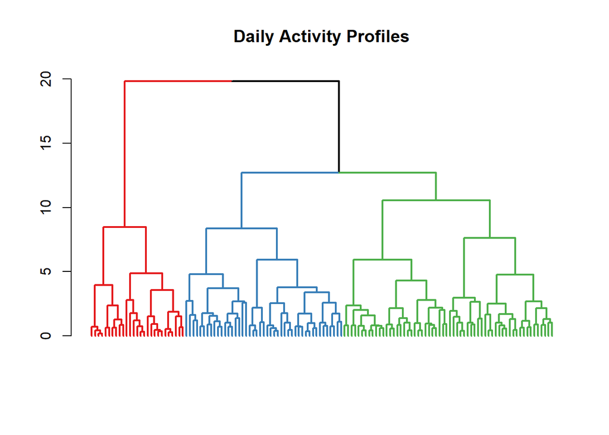

```r
k = 3
d <- dist(web_processed, method = "euclidean")
hc <- hclust(d, method = "ward.D2")
profile_cols <- brewer.pal(k, "Set1")
dend <- as.dendrogram(hc) |>
  color_branches(k = k, col = profile_cols) |>
  set("branches_lwd", 2)
plot(dend, leaflab = "none", main = "Daily Activity Profiles")
```

Based on the above dendrogram, we set $k=3$. To characterise the identified daily activity profiles, show the radar charts:

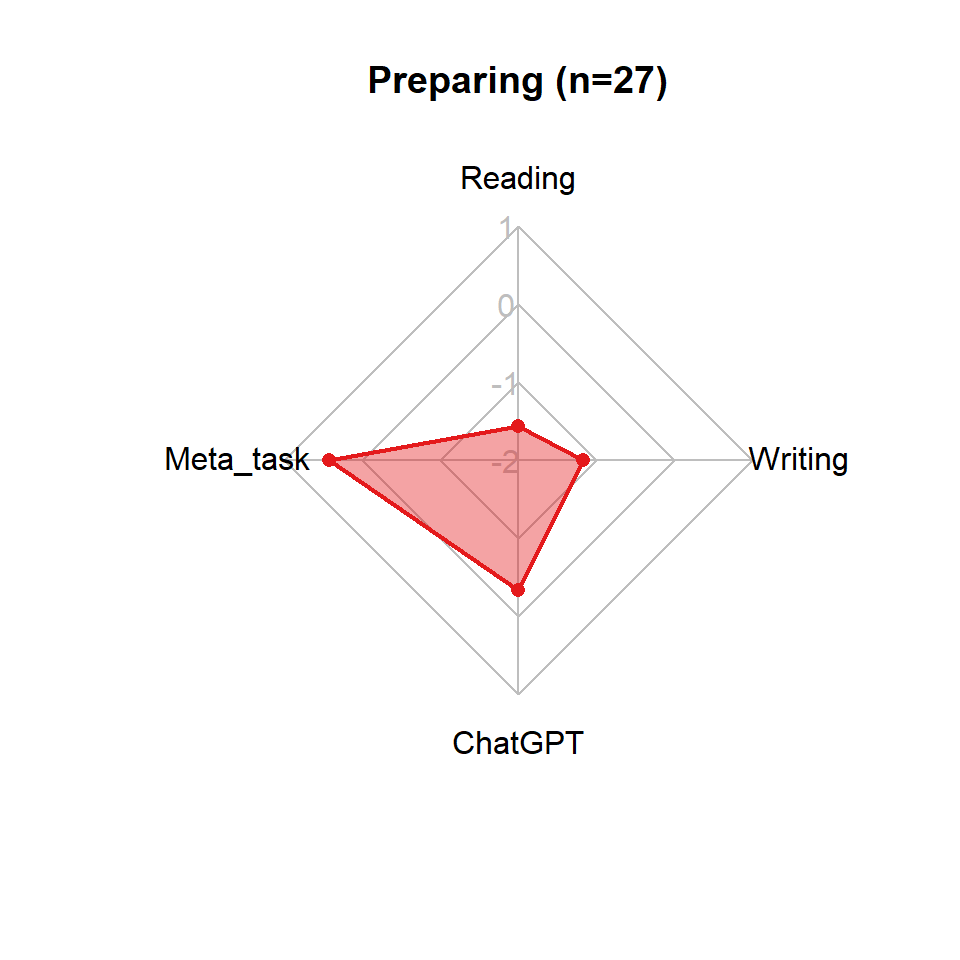

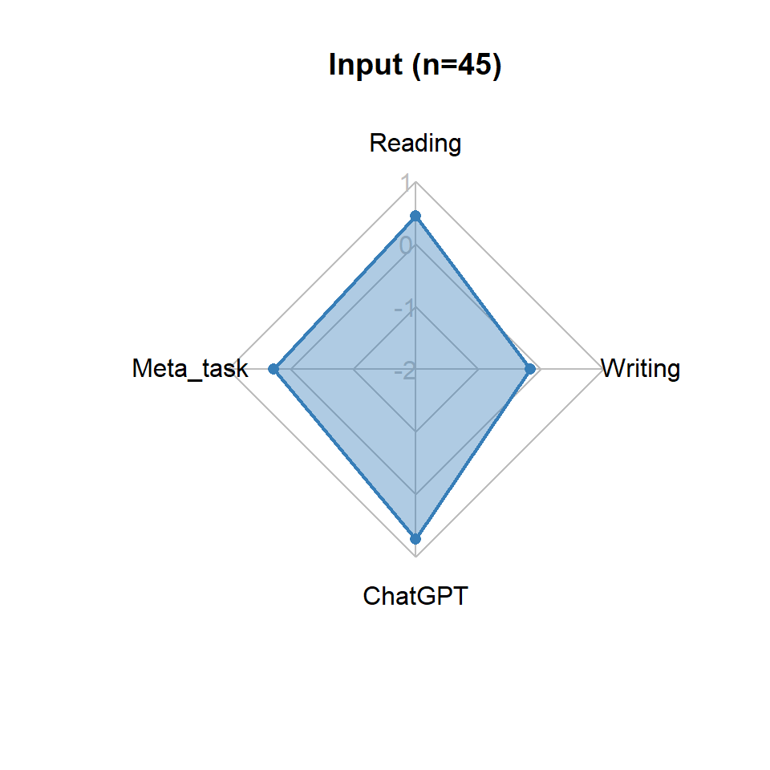

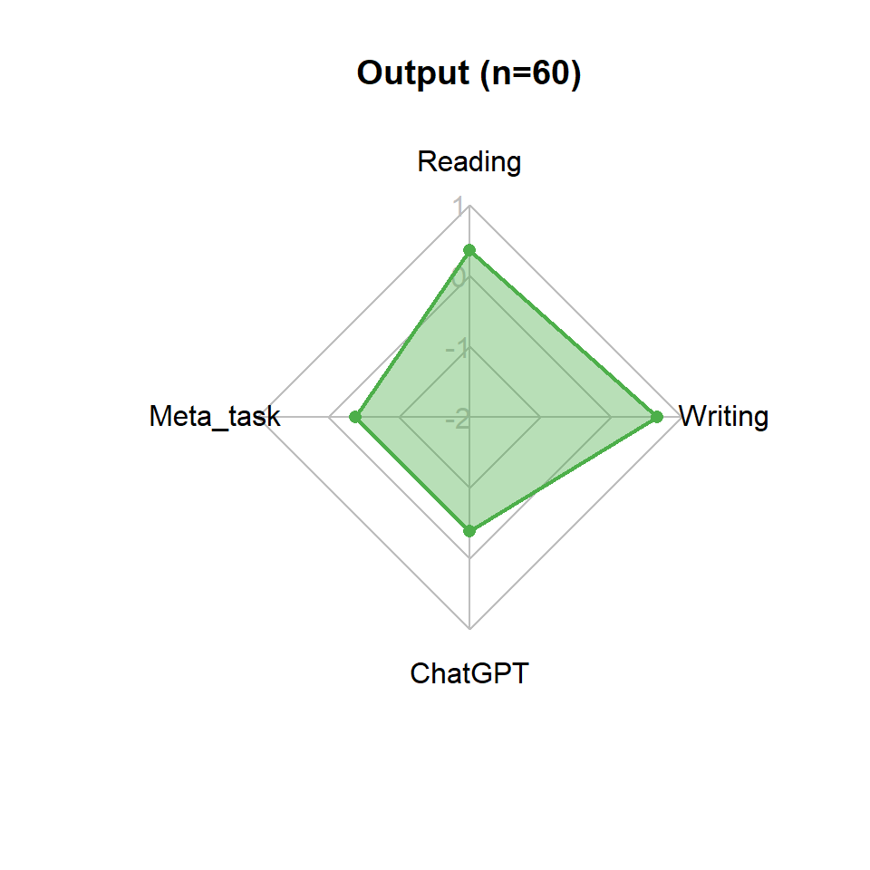

```r
k = 3
web_processed$Profile <- cutree(hc, k = k)

profile_means <- web_processed |>
  group_by(Profile) |>
  summarise(across(all_of(web_vars), \(x) mean(x, na.rm = TRUE)), .groups="drop")

gmin <- -2; gmax <- 1
scale_df <- data.frame(rbind(
  max = rep(gmax, length(web_vars)),
  min = rep(gmin, length(web_vars))
))
colnames(scale_df) <- web_vars

profiles <- c("Preparing", "Input", "Output")
for(i in 1:k) {
  df_plot <- bind_rows(
    scale_df,
    profile_means |> filter(Profile == i) |> select(all_of(web_vars))
  )
  rownames(df_plot)[3] <- paste0(profiles[i], " (n=",
                                  sum(web_processed$Profile==i), ")")
  radarchart(
    df_plot,
    axistype    = 1,
    seg         = gmax - gmin,
    caxislabels = seq(gmin, gmax, by = 1),
    pcol        = profile_cols[i],
    pfcol       = alpha(profile_cols[i], 0.4),
    plwd        = 2,
    cglcol      = "grey",
    cglty       = 1,
    axislabcol  = "grey",
    vlcex       = 1,
    centerzero  = TRUE,
    title       = paste0(profiles[i], " (n=",
                                  sum(web_processed$Profile==i), ")")
  )
}
```

Also illustrate how daily profiles unfold over time:

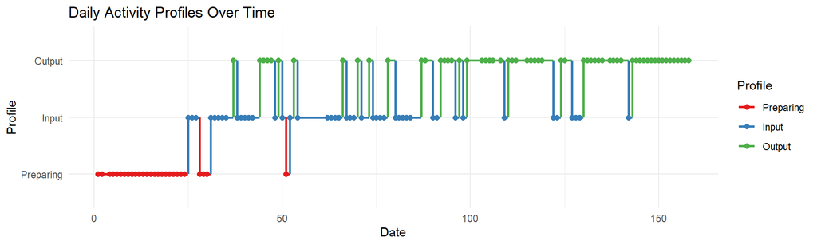

```r
web_processed$Date <- web$Date
ggplot(web_processed, aes(x = Date, y = as.factor(Profile), group = 1, color = as.factor(Profile))) +
  geom_step(linewidth = 1) +
  geom_point(size = 2) +
  scale_y_discrete(
    name   = "Profile",
    breaks = c("1","2","3"),
    labels = profiles
  ) +
  scale_color_brewer(
    palette = "Set1",
    name    = "Profile",
    labels  = profiles
  ) +
  labs(
    title = "Daily Activity Profiles Over Time",
    x     = "Date"
  ) +
  theme_minimal()
```

Now we perform TNA by daily activity profiles. First, the intra-day networks are shown below:

```
── Preparing Data ──────────────────────────────────────────────────────────────
```

```
ℹ Input data dimensions: 66 rows, 12 columns
ℹ No `time` or `order` column provided. Using `actor` as a session identifier.
ℹ Total number of sessions: 27
ℹ Number of unique users: 27
ℹ Total number of actions: 66
ℹ Maximum sequence length: 5 actions
```

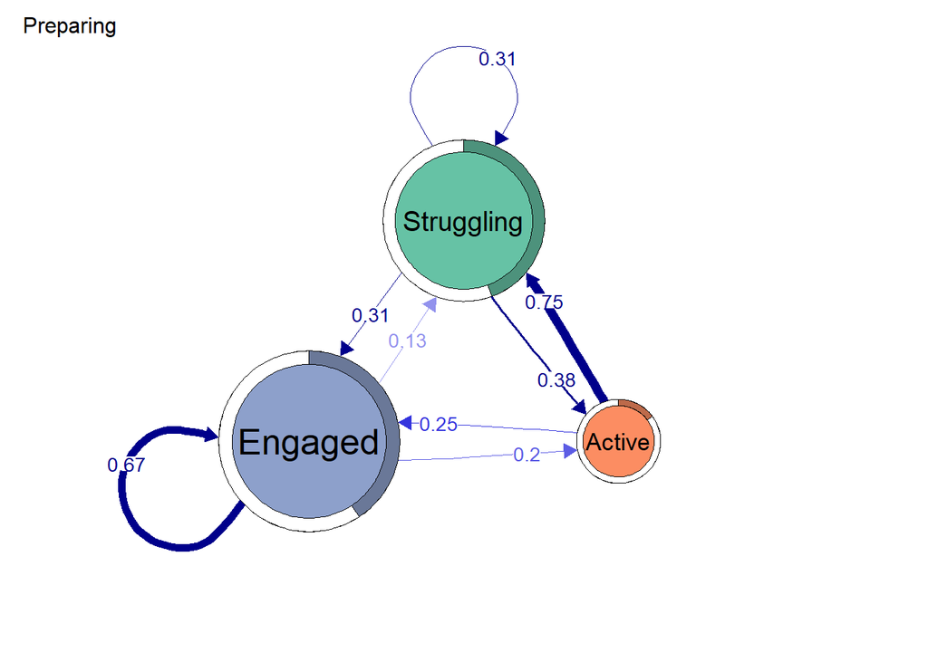

```
── Preparing Data ──────────────────────────────────────────────────────────────
ℹ Input data dimensions: 117 rows, 12 columnsℹ No `time` or `order` column provided. Using `actor` as a session identifier.ℹ Total number of sessions: 45ℹ Number of unique users: 45ℹ Total number of actions: 117ℹ Maximum sequence length: 5 actions
```

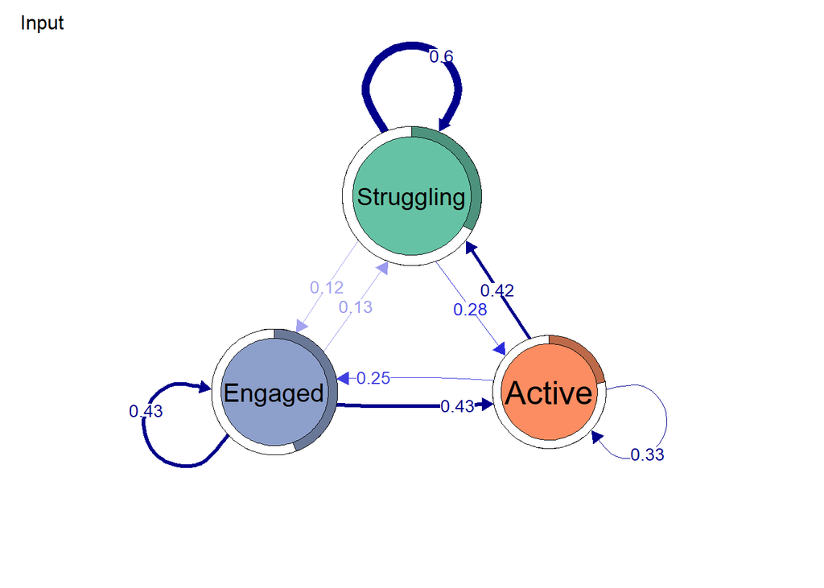

```
── Preparing Data ──────────────────────────────────────────────────────────────
ℹ Input data dimensions: 151 rows, 12 columnsℹ No `time` or `order` column provided. Using `actor` as a session identifier.ℹ Total number of sessions: 60ℹ Number of unique users: 60ℹ Total number of actions: 151ℹ Maximum sequence length: 5 actions
```

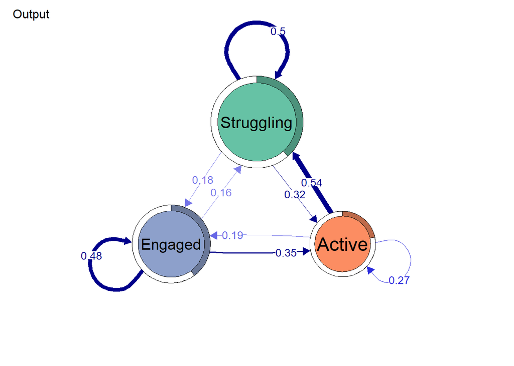

```r
profile_map <- web_processed |> select(all_of(c("Date", "Profile")))
df <- left_join(df_states, profile_map, by = "Date")
for (i in 1:k) {
  df_tmp <- df |> filter(Profile == i)
  tna_data <- prepare_data(df_tmp, action = "State", actor = "Date")
  net <- tna(tna_data)
  plot(
    net,
    colors = state_cols,
    vsize  = 50 * table(df_tmp[["State"]]) / nrow(df_tmp),
    layoutScale = 0.5,
    title = profiles[i]
  )
}
```

Then, show the inter-day transition networks:

```
── Preparing Data ──────────────────────────────────────────────────────────────
```

```
ℹ Input data dimensions: 66 rows, 12 columns
ℹ No `time` or `order` column provided. Treating the entire dataset as one
  session.
ℹ Total number of sessions: 1
ℹ Total number of actions: 66
ℹ Maximum sequence length: 66 actions
```

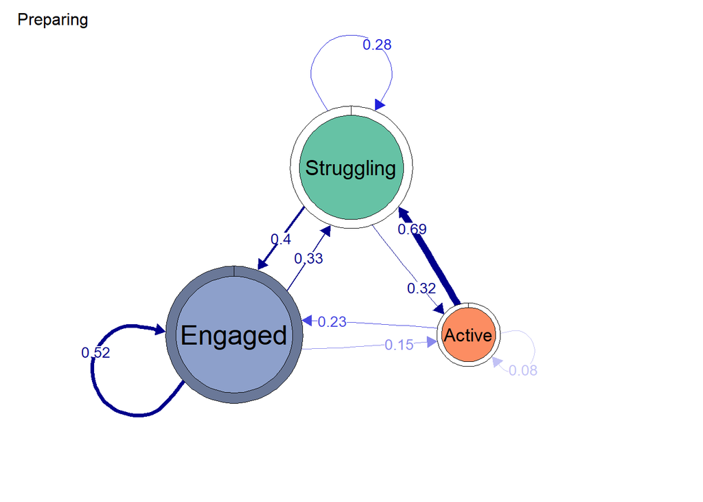

```
── Preparing Data ──────────────────────────────────────────────────────────────
ℹ Input data dimensions: 117 rows, 12 columnsℹ No `time` or `order` column provided. Treating the entire dataset as one
  session.ℹ Total number of sessions: 1ℹ Total number of actions: 117ℹ Maximum sequence length: 117 actions
```

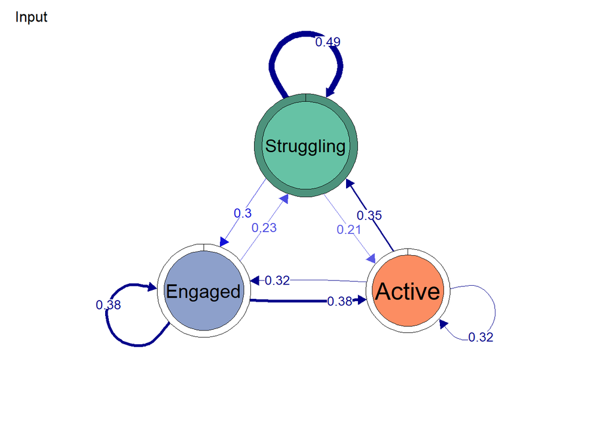

```
── Preparing Data ──────────────────────────────────────────────────────────────
ℹ Input data dimensions: 151 rows, 12 columnsℹ No `time` or `order` column provided. Treating the entire dataset as one
  session.ℹ Total number of sessions: 1ℹ Total number of actions: 151ℹ Maximum sequence length: 151 actions
```

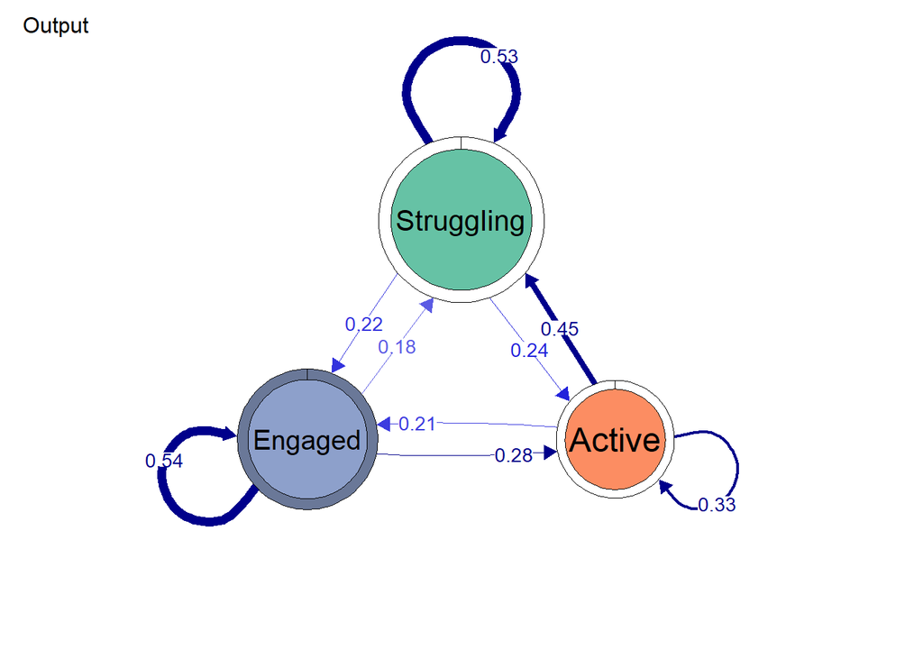

```r
profile_map <- web_processed |> select(all_of(c("Date", "Profile")))
df <- left_join(df_states, profile_map, by = "Date")
for (i in 1:k) {
  df_tmp <- df |> filter(Profile == i)
  tna_data <- prepare_data(df_tmp, action = "State")
  net <- tna(tna_data)
  plot(
    net,
    colors = state_cols,
    vsize  = 50 * table(df_tmp[["State"]]) / nrow(df_tmp),
    layoutScale = 0.5,
    title = profiles[i]
  )
}
```